# Descriptive analysis of environmental violence cases in Colombia

Lina Barbosa

*“Donde hay poca justicia es un peligro tener razon”*, Francisco de Quevedo

### Overview

This preliminary descriptive analysis that I am presenting is part of a research effort of the Environment at Energy Transitions Laboratory, co-lead by Professor Matto Mildenberger at University of California Santa Barbara. Our project seeks to better document and understand the consequences of violence against environmental leaders in the Global South. I have been collecting data on environmental violence in Colombia and I am certain that violence cases exceed a couple of hundreds. However, for the prupose of this brief analysis, I’m only using data on a total of 84 violent episodes that were collected from the Environmental Justice Atlas. The Environmental Justice Atlas is an online resource that collects data on environmental justice conflicts around the world. The EJ Atlas is my primary source of information, complemented with publicly available information.

The 84 violent episodes here presented, were collected from 18 environmental conflicts listed in the EJ atlas. By *violent episodes*, I am referring to cases in which environmental activists have experienced violent acts such as threats, attacks, attempt of murder or were murdered while playing their role of environmental leaders.

### Who are the environmental activists?

- 91% of environmental leaders are **males**, most of them are farmers, peasants, artisanal miners or employed at industrial firms.

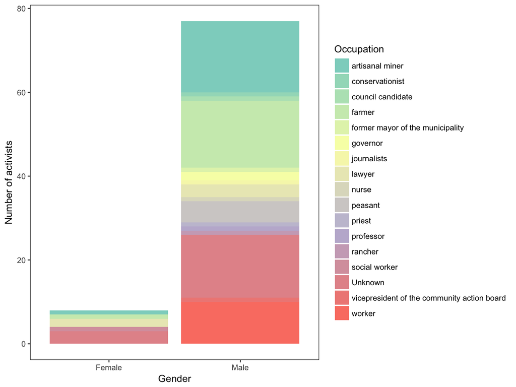

```r
activists <- RawData %>%
  select(ID, Gender, Occupation, Leadership) %>%
  mutate(Occupation = replace(Occupation, is.na(Occupation), "Unknown"),
         Leadership = replace(Leadership, is.na(Leadership), "Member of Social/Env Organization"))

# proportion of males and females

male_female <- activists %>%
  group_by(Gender) %>%
  summarise((count = n()/84)*100)

colourCount = length(unique(activists$Occupation))
getPalette = colorRampPalette(brewer.pal(9, "Set3"))

genderplot <- ggplot(activists, aes(Gender)) +
              geom_bar(aes(fill = Occupation)) +
              ylab("Number of activists") +
              scale_fill_manual(values = colorRampPalette(brewer.pal(4, "Set3"))(colourCount)) +
              theme_bw() +
              removeGrid (x=TRUE, y=TRUE)

genderplot
```

- Most of the environmental activists form part of a social organization. Some others are indigenous leaders, afro-Colombian leaders or political leaders.

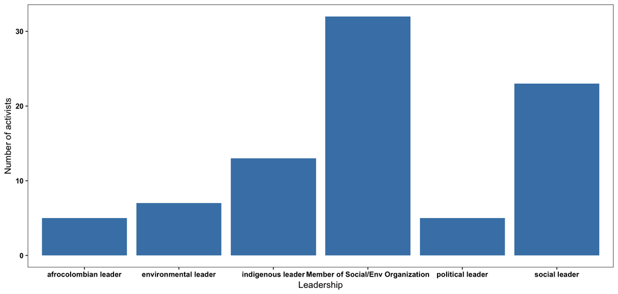

```r
leadershiplot <- ggplot(activists, aes(Leadership)) +
                 geom_bar(fill = "steelblue") +
                 ylab("Number of activists") +
                 theme_bw() +
                 #scale_x_discrete(labels = abbreviate) +
                 theme(axis.text = element_text(face ="bold", colour="black", size=9))+
                 removeGrid (x=TRUE, y=TRUE)
leadershiplot
```

### What are the main drivers of environmental conflicts?

According to my understanding on the social and political atmosphere in Colombia, I’ve classified environmental conflicts into 5 main categories that I consider are reprensentative of the situation:

- Land restitution
- Environmental damage
- Compensation
- Traditional livelihoods
- Crop substitution

- Mining
- Palm oil
- Oil&Gas
- Food Industry
- Hydropower

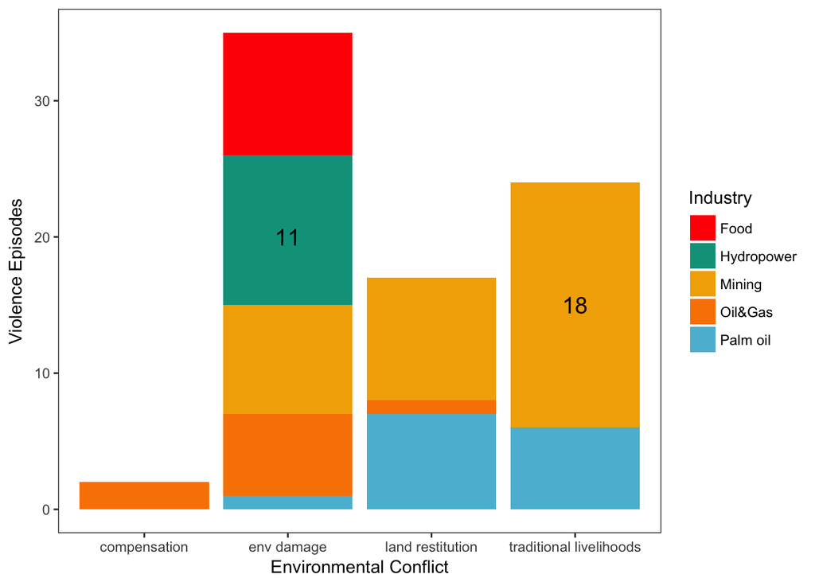

```r
conflicts <- RawData %>%
 filter(!is.na(Industry))

# number of conflicts per driver
drivers <- conflicts %>%
  group_by(Industry, Driver) %>%
  summarise(count = n())

conflict1 <- ggplot(conflicts, aes(Driver)) +
             geom_bar(aes(fill = Industry))+
             scale_fill_manual(values = c("#FF0000", "#00A08A",
                                          "#F2AD00", "#F98400",
                                          "#5BBCD6", "#ABDDDE")) +
             ylab("Violence Episodes") +
             xlab("Environmental Conflict") +
             annotate ("text", x="traditional livelihoods", y=15,
                       label="18", colour="black", size=5, hjust=0.5) +
             annotate ("text", x="env damage", y=20,
                       label="11", colour="black", size=5, hjust=0.5) +
             theme_bw() +
             removeGrid(x=TRUE, y=TRUE)

conflict1
```

- It can be observed that the mining industry is associated with 3 of the 5 types of environmental conflicts: Environmental damage, land restitution, and traditional livelihoods. In many rural areas in Colombia, dwellers demand the persistence of their traditional economic activities over industrial mining.
- Most of the environmental activists have claimed that environmental damages such as water pollution and soil degradation, are bringing not only negative consequences to biodiversity, but also social impacts.
- Just a couple of environmental conflicts relate to the unfulfillment of agreements between oil & gas industries and local communities in terms of environmental and social compensation.

### What is the total number of threats and murders?

```r
violence <- RawData %>%
  mutate(threaten = (ifelse(is.na(DateT),0,1))) %>%
  mutate(attacked = (ifelse(is.na(DateA),0,1))) %>%
  mutate(attmurder = (ifelse(is.na(DateAM),0,1))) %>%
  mutate(murdered = (ifelse(is.na(DateM),0,1)))

total <- summarize_at(violence, .vars = c("threaten" ,"attacked", "attmurder", "murdered"), .funs = sum)

threats <- filter(violence, threaten == 1) %>%
  summarize_at(.vars = c("attacked", "attmurder", "murdered"), .funs = sum)

nothreats <- filter(violence, threaten == 0) %>%
  summarize_at(.vars = c("attacked", "attmurder", "murdered"), .funs = sum)

Event <- c("", "", "Total")
Threatened <- c("Yes", "No", 33)
Murdered <- c(9, 44, 54)

events <- cbind(Event,Threatened, Murdered)
events <- as.tibble(events)

Dates <- RawData %>%
  mutate(D1 = DateM - DateT,
         D2 = DateM - DateAM,
         D3 = DateM - DateA,
         D4 = Date_EnvM - Date_to)

# Average number of days that pass between a threat and an assassination
meanM <- mean(Dates$D1, na.rm = T) # 60 days
# Average number of days that pass between an attempt of murder and a murder
meanAM <- mean(Dates$D2, na.rm = T) # 73 Days
meanMov <- mean(Dates$D4, na.rm = T) # 7 years

knitr::kable(events)
```

| Event | Threatened | Murdered |
| --- | --- | --- |
|  | Yes | 9 |
|  | No | 44 |
| Total | 33 | 54 |

- Of a total of 54 murdered activists, **only 9 received previous notification** by means of a threat
- Only **1 leader** was murdered after being attacked

### How much time passes between a threat and an assassination?

- On average **60 days pass** before a threat turns into a fatality. However, assassinations can happen rapidly between the first 5 days after receiving a threat
- 73 days passed when a leader was murdered after being attacked

### What’s the most violent industry?

- Most of the environmental crimes are committed by people in the mining sector (T&M)
- It is Highly risky to fight for land rights and traditional livelihoods

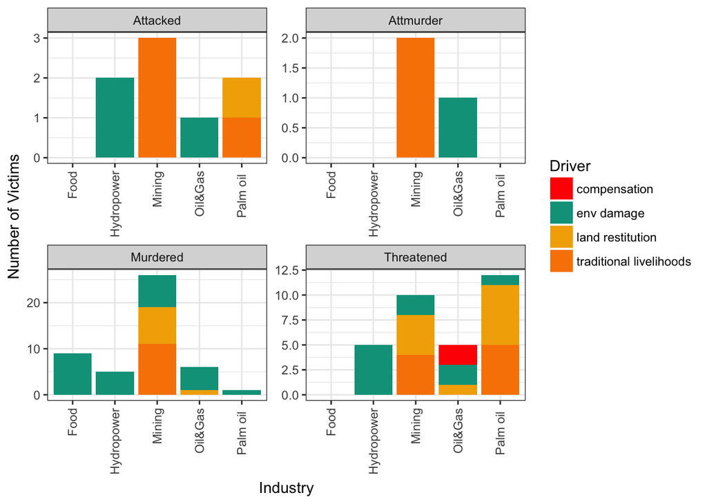

```r
filter(violence, !is.na(Industry)) %>%
  group_by( Industry, Driver) %>%
  summarise(Threatened = sum(threaten),
            Attacked = sum(attacked),
            Attmurder = sum(attmurder),
            Murdered = sum(murdered)) %>%
  gather(Outcome, Count, -c(Industry, Driver)) %>%
  ggplot(aes(x = Industry, y = Count, fill = Driver)) +
  geom_col() +
  ylab("Number of Victims") +
  scale_fill_manual(values = wes_palette("Darjeeling1")) +
  theme_bw() +
  facet_wrap(~Outcome, scales = "free") +
  ggExtra::rotateTextX()
```

### How long passes between the start date of a project and environmental movilizations?

- On average 7 years. Max 14 years, Min 1 year (env damage & public consultation)

### How long does it take to satisfy activists’ demands?

```r
status <- Dates %>%
  filter(Outcome == "Success") %>%
  mutate(D5 = Date_ti - Date_EnvM)

status2 <- Dates %>%
  filter(Outcome == "Failure") %>%
  mutate(D5 = Date_ti - Date_EnvM)
```

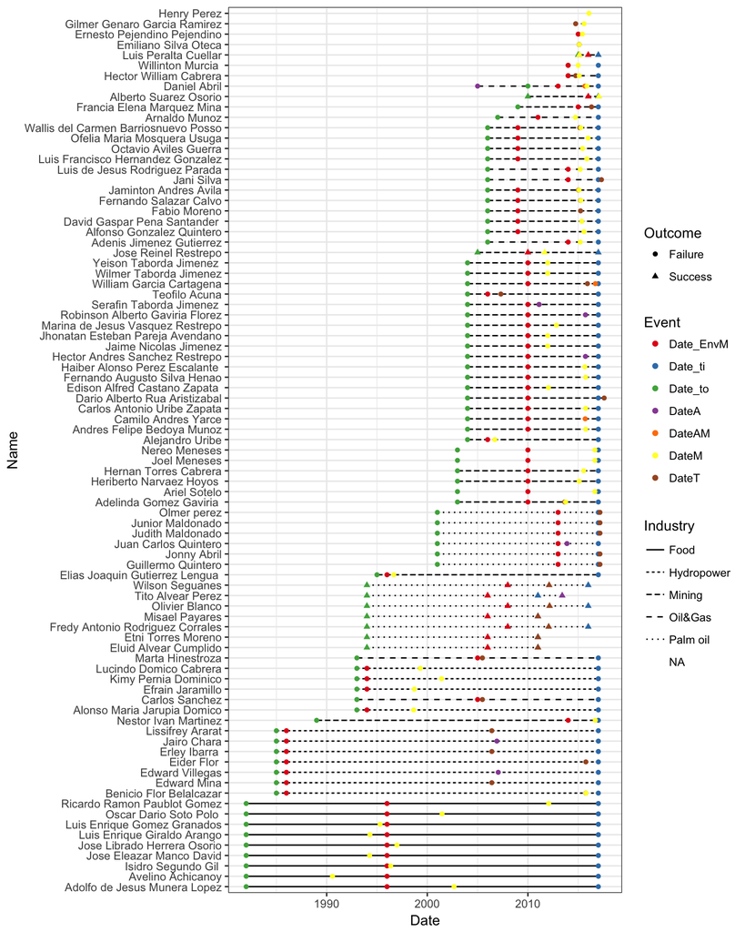

```r
select(violence, Name, Perpetrator, Outcome, Driver, Industry, contains("Date")) %>%
  transform(Name = reorder(Name, Date_to)) %>%
  gather(Event, Date, -c(Name, Perpetrator, Outcome, Driver, Industry)) %>%
  filter(!is.na(Date)) %>%
  ggplot(aes(x = Date, y = Name)) +
  geom_line(aes(linetype = Industry)) +
  geom_point(aes(shape = Outcome, color = Event)) +
  theme_bw() +
  scale_color_brewer(palette = "Set1")
```

### What are the criminal entities accountable for the environmental crimes?

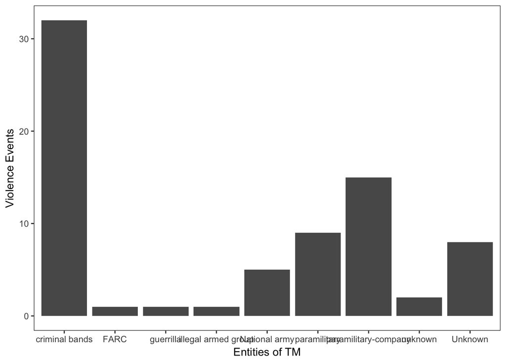

```r
criminals <- violence %>%
  group_by(EntitiesTM) %>%
  summarise(count = n()) %>%
  filter(!is.na(EntitiesTM))

criminalsplot <-  ggplot(criminals, aes(x = EntitiesTM, y = count)) +
             geom_col() +
             ylab("Violence Events") +
             xlab("Entities of TM") +
             theme_bw() +
             removeGrid(x=TRUE, y=TRUE)

criminalsplot
```

```r
criminals2 <- violence %>%
  group_by(Perpetrator, murdered) %>%
  filter(!is.na(EntitiesTM), murdered == 1) %>%
  summarise(count = n())
```